# Mapas en acción. Analítica avanzada

Author

Tomás Bustos

# Mapas en acción: Análisis y visualización espacial con R

## 4. Analítica avanzada

Despejando el ruido. Aquí se buscará identificar patrones regionales del voto en la Ciudad de Buenos Aires.

## 4.1. Pregunta-problema

El objetivo será analizar las elecciones en la Ciudad de Buenos Aires a nivel de circuito electoral. ¿Cómo es el patrón regional del voto en la Ciudad de Buenos Aires?

Cargamos las librerías.

```r
library(tidyverse)
library(sf)
library(patchwork)
library(spdep)
```

## 4.2. Unidades de agregación

La información electoral tiene distintos niveles de agregación. En general se trabaja a nivel distrito (provincias), a nivel sección o a nivel circuitos electorales.

```r
cir <- st_read(params$ruta_circuitos_caba) %>%
  mutate(indice_feminidad = FEMENINO / MASCULINO * 100)
dim(cir)
```

```
[1] 167  11
```

```r
head(cir,2)
```

```
Simple feature collection with 2 features and 10 fields
Geometry type: MULTIPOLYGON
Dimension:     XY
Bounding box:  xmin: 107875.7 ymin: 99970.68 xmax: 109156.2 ymax: 101508.9
Projected CRS: Argentina_GKBsAs
   ID CIRCUITO_N COMUNA    BARRIO TOTAL MASCULINO FEMENINO PERIMETRO     AREA
1 001          1      1 SAN TELMO 11377      5695     5682  4157.176 709721.6
2 002          2      1 SAN TELMO 11365      5870     5495  3045.859 523430.9
                        geometry indice_feminidad
1 MULTIPOLYGON (((108906 1009...         99.77173
2 MULTIPOLYGON (((107881.9 10...         93.61158
```

Se realiza la agregación espacial para conseguir la geometría a nivel sección y a nivel distrito.

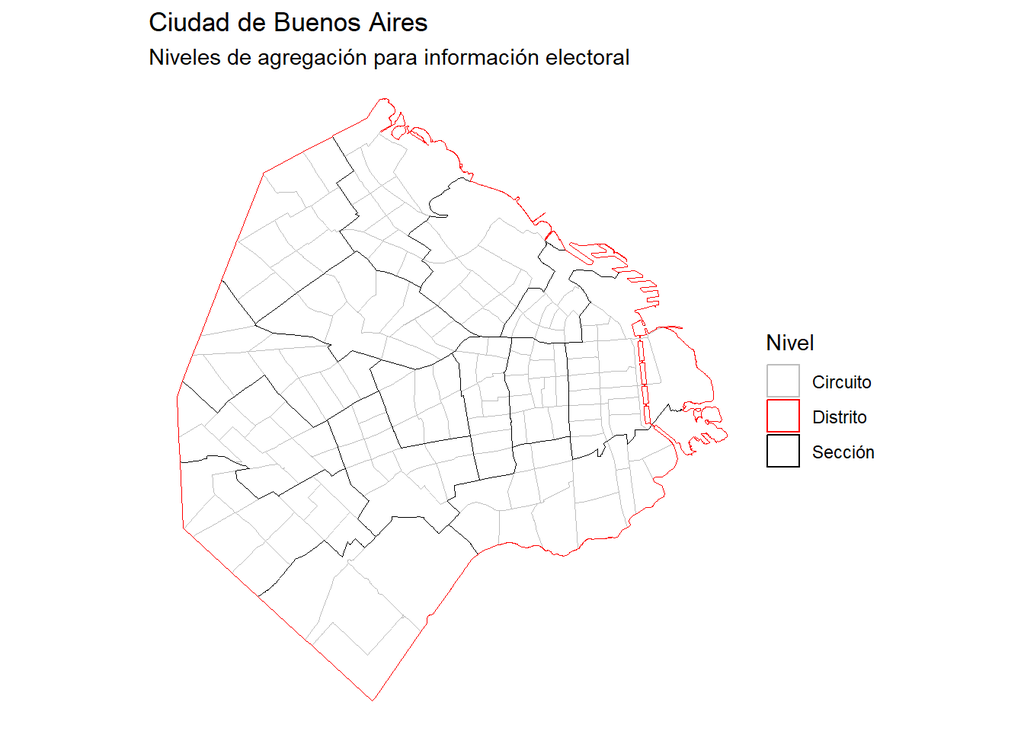

```r
sec <- cir %>%
  group_by(COMUNA) %>%
  summarise(geometry = st_union(geometry),
            MASCULINO = sum(MASCULINO),
            FEMENINO = sum(FEMENINO)) %>%
  mutate(indice_feminidad = FEMENINO / MASCULINO * 100)

dis <- cir %>%
  mutate(distrito="CABA") %>%
  group_by(distrito) %>%
  summarise(geometry = st_union(geometry),
            MASCULINO = sum(MASCULINO),
            FEMENINO = sum(FEMENINO)) %>%
  mutate(indice_feminidad = FEMENINO / MASCULINO * 100)

ggplot()+
  geom_sf(data=cir, aes(color="Circuito"), fill=NaN)+
  geom_sf(data=sec, aes(color="Sección"), fill=NaN)+
  geom_sf(data=dis, aes(color="Distrito"), fill=NaN)+
  scale_color_manual(name = "Nivel",  values = c("Circuito" = "gray","Sección" = "black","Distrito" = "red"))+
  labs(title="Ciudad de Buenos Aires",
       subtitle="Niveles de agregación para información electoral")+
  theme_void()
```

Cada nivel de agregación requiere su propio cálculo, ya que cada unidad pesan de manera diferencial en el agregado.

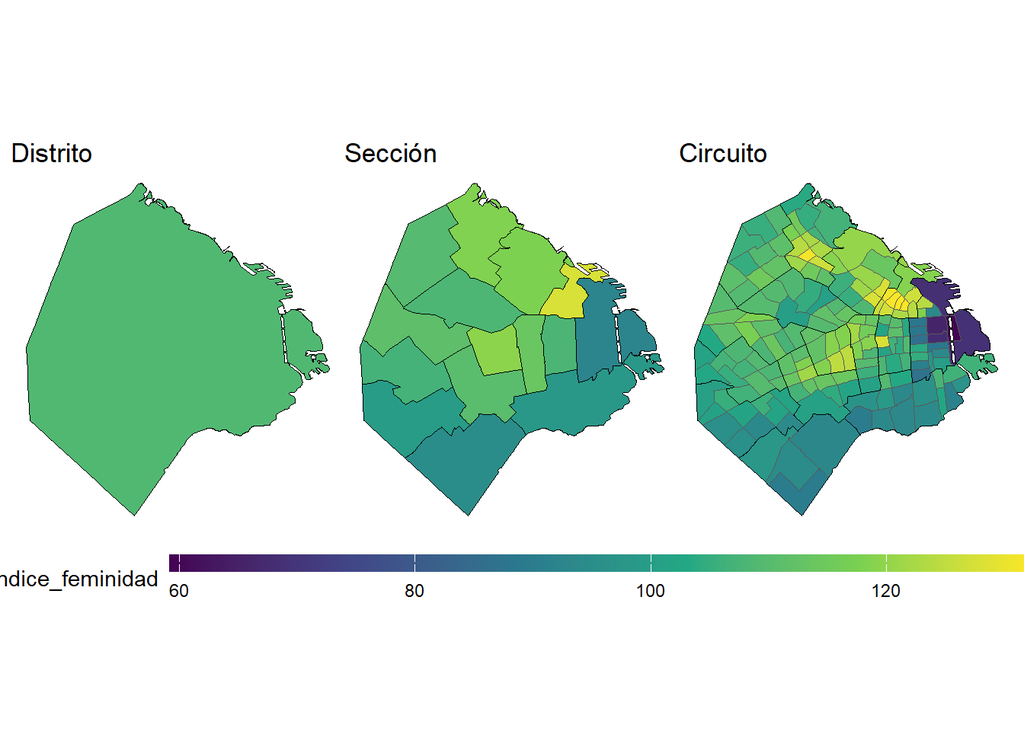

```r
limites <- range(
  c(dis$indice_feminidad, sec$indice_feminidad, cir$indice_feminidad))

plot_dis <- ggplot(data=dis)+
  geom_sf(aes(fill=indice_feminidad), color="black")+
  scale_fill_viridis_c(limits = limites)+
  labs(title="Distrito")+
  theme_void()

plot_sec <- ggplot(data=sec)+
  geom_sf(aes(fill=indice_feminidad), color="black")+
  scale_fill_viridis_c(limits = limites)+
  labs(title="Sección")+
  theme_void()

plot_cir <- ggplot(data=cir)+
  geom_sf(aes(fill=indice_feminidad))+
  geom_sf(data=sec, color="black", fill=NaN)+
  scale_fill_viridis_c(limits = limites)+
  labs(title="Circuito")+
  theme_void()

(plot_dis + plot_sec + plot_cir) +
  plot_layout(guides = "collect") &
  theme(legend.position = "bottom",
    legend.key.width = unit(3, "cm"),
    legend.key.height = unit(0.3, "cm"))
```

Carguemos las bases de datos.

```r
# seleccionamos las columnas imprescindibles
cir_clean <- cir %>%
  select(CIRCUITO_N, geometry)

# cargamos resultados y pegamos a la base de circuitos
gdf <- read_csv(params$ruta_resultados_caba) %>%
  filter(anio==2023) %>%
  mutate(porcentaje = votos / votos_totales * 100) %>%
  left_join(cir_clean, by=c("circuito"="CIRCUITO_N")) %>%
  st_as_sf()

head(gdf,2)
```

```
Simple feature collection with 2 features and 14 fields
Geometry type: MULTIPOLYGON
Dimension:     XY
Bounding box:  xmin: 107893 ymin: 99970.68 xmax: 109156.2 ymax: 100976.3
Projected CRS: Argentina_GKBsAs
# A tibble: 2 × 15
   anio tipo_eleccion tipo_resultado cargo    distrito seccion comuna   circuito
  <dbl> <chr>         <chr>          <chr>    <chr>      <dbl> <chr>       <dbl>
1  2023 G             provisorio     DIP_CABA CABA           1 comuna …        1
2  2023 G             provisorio     DIP_CABA CABA           1 comuna …        1
# ℹ 7 more variables: partido <chr>, votos <dbl>, electores <dbl>,
#   votos_totales <dbl>, partido_agrup <chr>, porcentaje <dbl>,
#   geometry <MULTIPOLYGON [m]>
```